# Robust Statistics Untuk Nilai Tengah

Bagus Sartono dan Amalia Kholifatunnisa (G14170010)

Rabu, 22 Juli 2020

#### **Pendahuluan**

Ukuran Pemusatan (*tendency central*) suatu himpunan data merupakan titik tempat dimana nilai-nilai suatu gugus data cenderung mengelompok, menunjukkan titik tengah suatu histogram atau kurva distribusi frekuensi. Salah satu kegunaan dari ukuran pemusatan data adalah untuk membandingkan dua populasi atau sampel, karena sangat sulit untuk membandingkan masing-masing anggota dari masing-masing anggota populasi atau masing-masing anggota data sampel. Rata-rata atau juga dikenal dengan istilah nilai tengah adalah ukuran yang paling sering digunakan dalam kehidupan sehari-hari, misalnya rata-rata upah karyawan, rata-rata harga beras, dll. Namun, nilai rata-rata ini akan sangat dipengaruhi oleh adanya pencilan (outlier) dan hanya bisa diterapkan untuk data yang diukur dalam skala interval atau rasio. Adanya data pencilan yang besar akan menyebabkan rata-rata contoh menjadi lebih besar dari yang seharusnya, sedangkan data pencilan yang kecil menyebabkan nilai rata-rata contoh menjadi rendah dari yang seharusnya. Sehingga, hal tersebut melatarbelakangi bahwa rata-rata tidak bersifat kekar (*robust*) karena nilainya mudah terganggu akibat keberadaan pencilan terutama jika gugus datanya tidak besar.

#### *Trimmed Mean*

Rataan terpangkas (*Trimmed Mean*) merupakan nilai rata-rata hitung sekelompok data yang telah diurutkan dan berada di tengah data, tepatnya data di 1 - $2\alpha$ bagian tengah dari data dengan $0 < \alpha < 1$. Hal ini berarti sebanyak $\alpha n$ data paling besar dan $\alpha n$ data paling kecil disisihkan dan tidak ikut dalam perhitungan rataan. *Trimmed Mean* ini merupakan salah satu cara untuk mengatasi sensitifas rata-rata terhadap nilai ekstrem atau pencilan.

Rataan terpangkas $2\alpha$ selanjutnya dapat dituliskan sebagai berikut:

$\overline{y}_{Ta}$ = $\frac{1}{n-2[\alpha n]}$ $\sum_{i = [\alpha n]+1 }^{n-[\alpha n]} y(i)$

dengan $y_{(1)}$,$y_{(2)}$,...,$y_{(n )}$ adalah data terurut dari contoh $y_{1}$,$y_{2}$,...,$y_{n}$

Rata-rata terpangkas ini dihitung dengan terlebih dahulu mengurutkan data dari nilai terkecil ke terbesar, kemudian menghapus nilai terpilih pada masing-masing ujung data terurut, dan kemudiang merata-ratakan nilai sisanya. Persentase pemangkasan dihitung sebagai berikut (Peck et al., 2008):

persentase pemangkasan = $\frac{banyaknya data yang dihapus pada setiap sisi}{n}$ x 100%

Sebagai ilustrasi terdapat data 5,49,49,50,60,65,65,70,75,100. Jika dihitung rataannya diperoleh nilai sebesar 58.8 dan cenderung tidak menggambarkan pemusatan data secara baik karena memiliki nilai lebih kecil dari sebagian besar amatan. Hal ini dipengaruhi adanya amatan bernilai ekstrem. Namun, apabila dua amatan ekstrem 5 dan 100 dihilangkan, kita akan memperoleh persentase rata-rata terpangkas sebagai berikut :

persentase pemangkasan = $\frac{2}{10}$ x 100% = 20%

Rataan terpangkas 20% dari gugus data diperoleh dengan membuang (10%x10) = 1 amatan paling besar dan (10%x10)= 1 amatan paling kecil, sehingga tersisa 8 amatan dengan hasil nilai rataan yang sesuai sebesar 60.375.

Untuk lebih memudahkan proses rataan terpangkas ini, kita dapat melakukannya menggunakan program R dengan fungsi `mean()` dan menambahkan opsi trim sebagai persentase pemangkasan pada masing - masing ujung kiri dan kanan data.

```r
#contoh 1
ex <- c(5,49,49,50,60,65,65,70,75,100)
mean(ex, trim = 0.1) # membuang [10%x10] = 1 amatan terbesar dan [10%x10] = 1 amatan terkecil
```

```
## [1] 60.375
```

```r
#contoh 2
con <- c(12,12,12,13,13,14,16,17,18,18,19,19,19,19,20,20,21,22,22,67)
mean(con, trim =0.05) # membuang [5%x20] = 1 amatan terbesar dan [5%x20} = 1 amatan terkecil
```

```
## [1] 17.44444
```

#### *Winsorized Mean*

*Winsorized mean* adalah metode rata-rata yang awalnya menggantikan nilai terkecil dan terbesar dengan pengamatan terdekat. Hal ini dilakukan untuk membatasi efek dari nilai ekstrim abnormal atau outlier pada perhitungan. *Winsorized* dapat dinyatakan dalam dua cara, pertama mengacu pada penggantian pengamatan '$\alpha n$' atau 'k' terkecil dan terbesar. Kedua, penggantian mengacu pada "X%"yang berarti mengganti persentase nilai yang diberikan dari kedua ujung data. Sehingga *Winsorized mean* didefinisikan sebagai berikut.

$\overline{y}_{Wa}$ = $\frac{1}{n}$ $\left(\left([\alpha n]+1 \right) y_{[\alpha n]+1} + \sum_{i = [\alpha n]+1 }^{n-[\alpha n]} y(i) + (\left([\alpha n]+1 \right) y_{n-[\alpha n]} \right)$

dimana $\alpha n$ amatan terkecil diganti nilainya dengan nilai amatan $y_{[\alpha n]+1}$ dan $\alpha n$ amatan terbesar diganti nilainya dengan nilai amatan $y_{n-[\alpha n]}$.

Selanjutnya pada *Winsorized mean* setelah menggantikan nilai terkecil dan terbesar dengan pengamatan terdekat, selanjutnya menjumlahkan semua nilai amatan dan membaginya dengan jumlah total amatan.

Untuk memudahkan perhitungan dengan *Winsorized mean*, kita dapat menggunakan program R dengan fungsi `winsorMEAN()` dan argumen berupa vektor data serta proporsi dari data terkecil dan data terbesar yang akan diganti. Program R ini memberikan default nilai proporsi masing-masing 0.05 dan 0.95 yang mengindikasikan 5% data terbesar dan 5% data terkecil akan diganti dengan nilai pada ttik Q(0.05) dan Q(0.95). Sehingga, untuk proporsi selainnya, misalkan 10% perlu pengaturan kembali pada syntax program R. Berikut ini ilustrasi *Winsorized mean* pada program R.

```r
winsorMEAN <- function(x,probs=c(0.05,0.95)) {
  xq <- quantile(x, probs = probs)
  x[x < xq[1]] <- xq[1]
  x[x > xq[2]] <- xq[2]
  return(mean(x))
}
ex <- c(5,30,49,49,50,60,65,65,70,75,98,100)
winsorMEAN(ex)
```

```
## [1] 60.72083
```

```r
winsorMEAN(ex, probs = c(0.10,0.90))
```

```
## [1] 61.51667
```

Berdasarkan hasil di atas, terdapat dua nilai *Winsorized mean* dengan nilai $\alpha$ sebesar 5 % dan 10%.

```r
library(psych)
ex <- c(5,30,49,49,50,60,65,65,70,75,98,100)
winsor.mean(ex, trim = 0.05)
```

```
## [1] 60.72083
```

```r
winsor.mean(ex, trim = 0.1)
```

```
## [1] 61.51667
```

Syntax di atas merupakan cara lain dari perhitungan *Winsorized mean* yaitu melalui packages psych dengan fungsi `winsor.mean()` dan pada fungsi ini terdapat opsi trim untuk menentukan nilai $\alpha$ yang digunakan. Hasil dari dua cara di atas menunjukkan kesamaan nilai.

#### *M-ESTIMATOR*

*M-ESTIMATOR* merupakan salah satu metode pendugaan parameter yang kekar terhadap keberadaan outlier dan memiliki efisiensi mencapai hingga 95%. Huruf M menunjukkan estimasi berdasarkan “tipe maksimum likelihood”. M-Estimasi memenuhi sifat sebagai estimator dengan syarat tak bias dan memiliki ragam minimum. M-Estimasi merupakan perluasan dari MLE (Maximum Likelihood ) dan merupakan estimasi yang robust (Yuliana dan Susanti, 2008). Pada metode ini dimungkinkan untuk mengeliminasi beberapa data, akan tetapi dalam beberapa kasus tidak selalu tepat dilakukan apalagi jika yang dieliminasi tersebut merupakan data penting atau bibit unggul yang kasusnya sering ditemui dalam bidang pertanian (Susanti, dkk., 2009; Susanti dan Pratiwi, 2012).

Secara umum, kita dapat mencari penduga rata-rata $\mu$ dengan meminimumkan besaran

$\sum_{i = 1}^{n} \rho (x_{i}-\mu)$

dengan $\rho (-)$ adalah suatu fungsi tertentu, sehingga untuk meminimumkan formula di atas kita dapat menggunakan turunannya.

$\sum_{i = 1}^{n} \rho' (x_{i}-\mu)$ = 0

dengan $\rho' (-)$ merupakan turuna pertama dari $\rho (-)$.

Penduga M bagi $\mu$ merupakan penduga yang didapatkan dengan menyelesaikan persamaan berikut.

$\sum_{i = 1}^{n} \psi (x_{i}-\mu)$ = 0

untuk $\psi$ merupakan suatu fungsi tertentu. Fungsi pengaruh $\psi$ dipilih secara umum dengan cara titik data yang berisi galat besar akan diberi bobot kecil. Terdapat banyak kriteria yang dapat digunakan sebagai fungsi pengaruh, seperti: Huber, Hampel, dan Bisquare.

### 1. Huber

Fungsi Huber mempunyai fungsi $\psi (•)$ yang monoton dan tidak memberikan bobot pada residu yang besar seperti pada kuadrat terkecil. Bentuk fungsi Huber yaitu sebagai berikut.

$\psi(x)$ =$\begin{cases} -c &; x < c,\\x &; |x|\le c , \\c &; x > c \end{cases}$

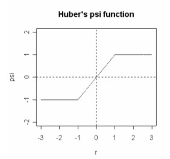

Berikut ini ilustrasi pendugaan rata-rata dengan fungsi Huber pada program R.

```r
library(MASS)
ex <- c(5,30,49,49,50,60,65,65,70,75,98,100)
huber(ex, k = 1.5, tol = 1e-06)  # k is winsorizes at k standard deviations
```

```
## $mu
## [1] 60.37501
##
## $s
## [1] 19.2738
```

Berdasarkan syntax di atas, nilai y merupakan vektor nilai data dan tol merupakan toleransi konvergensi. Output dari syntax di atas adalah nilai dugaan rata-rata dan perkiraan skala MAD (s).

### 2. Tukey's Bisquare

Fungsi pengaruh Tukey's Bisquare ini memiliki bentuk fungsi sebagai berikut.

$\psi(x)$ = x $\left[ 1 - (\frac{x}{R})^{2}\right]^{2}$, dengan $|x|\le R$

Pada persamaan di atas, nilai R dinyatakan dengan tuning constant. Tuning constant dalam regresi robust menentukan kerobusan penaksir terhadap pencilan dan efisiensi penaksir dalam ketidakadanya pencilan. Jika diambil α = 5%, maka estimasi-M Huber akan efektif digunakan bila R = 1,345 sedangkan pada Tukey's Bisquare untuk data sebaran normal, R efisien bernilai 4,685.

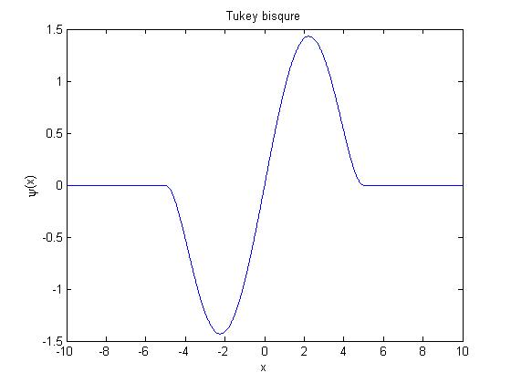

Berikut ini ilustrasi pendugaan rata-rata dengan fungsi Tukey's Bisquare pada program R.

```r
# pastikan telah menginstall packages qrmix
library(qrmix)   #memanggil packages qrmix yang telah tersimpan
set.seed(1)
x = rnorm(200, mean = 3)
y = Bisquare(x, c = 4.685)
```